# Sumamry Summary

Ottavia M. Epifania

15/6/2021

## Distribuzione normale

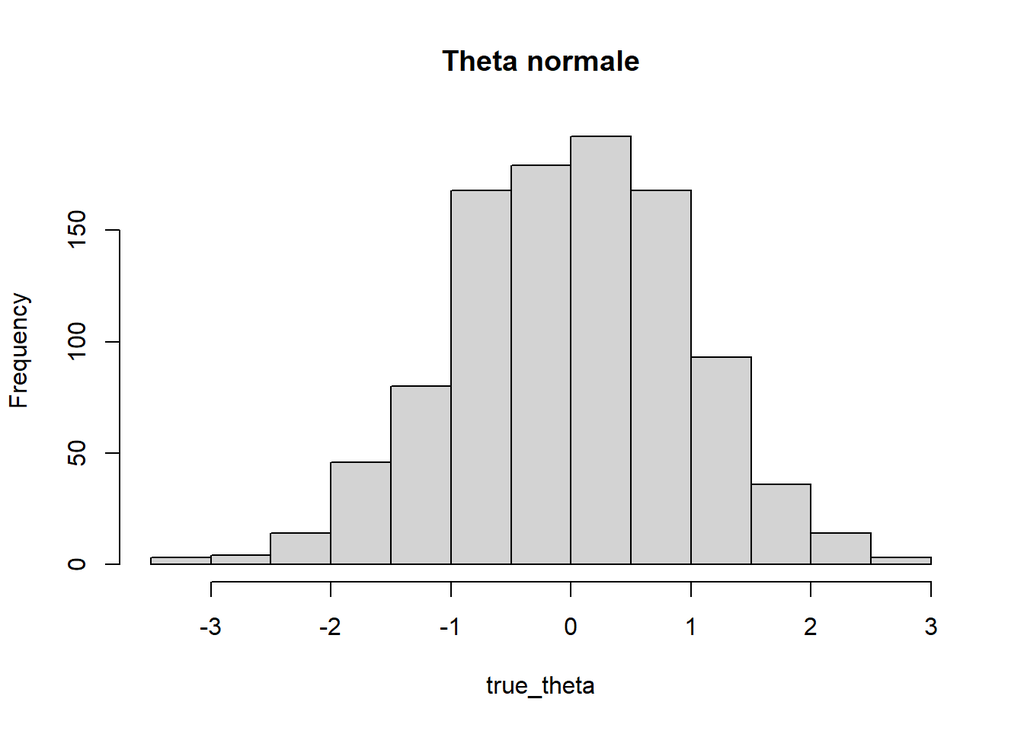

```r
set.seed(666)
N <- 1000  # number of persons
b <- runif(100, -3, 3)
a = c(runif(100, 0.4, 2))
true_theta = rnorm(N, mean = 0, sd = 1)
data <- sirt::sim.raschtype(true_theta, b = b, fixed.a = a)


diff_true <- matrix(cbind(1:length(b), b), ncol = 2)
discr_true = array(c(rep(0, length(a)), a), c(length(a),
    2, 1), dimnames = list(paste0("I", 1:length(a)),
    c("Cat0", "Cat1"), "Dim01"))

hist(true_theta, main = "Theta normale")
```

## Distribuzione Skewness “normale”

```r
library(PearsonDS)
set.seed(666)
moments <- c(mean = -2, variance = 1, skewness = 0.71,
    kurtosis = 4)
true_theta_sk <- c(rpearson(1000, moments = moments))
b <- runif(100, -3, 3)
a = c(runif(100, 0.4, 2))
data_sk <- sirt::sim.raschtype(true_theta_sk, b = b,
    fixed.a = a)

diff_true <- matrix(cbind(1:length(b), b), ncol = 2)
discr_true <- array(c(rep(0, length(a)), a), c(length(a),
    2, 1), dimnames = list(paste0("I", 1:length(a)),
    c("Cat0", "Cat1"), "Dim01"))
summary(true_theta_sk)
```

```
##    Min. 1st Qu.  Median    Mean 3rd Qu.    Max.
##  -4.569  -2.723  -2.117  -2.023  -1.431   1.010
```

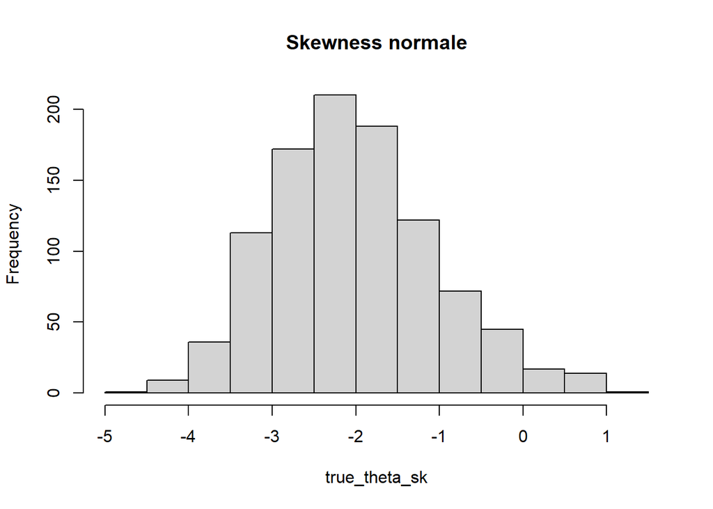

```r
hist(true_theta_sk, main = "Skewness normale")
```

## Skewness estrema

```r
set.seed(666)
moments <- c(mean = -2, variance = 2, skewness = 1.71,
    kurtosis = 8)
true_theta_sk_ex <- c(rpearson(1000, moments = moments))
b <- runif(100, -3, 3)
a = c(runif(100, 0.4, 2))
data_sk_ex <- sirt::sim.raschtype(true_theta_sk_ex,
    b = b, fixed.a = a)

diff_true <- matrix(cbind(1:length(b), b), ncol = 2)
discr_true <- array(c(rep(0, length(a)), a), c(length(a),
    2, 1), dimnames = list(paste0("I", 1:length(a)),
    c("Cat0", "Cat1"), "Dim01"))

summary(true_theta_sk_ex)
```

```
##    Min. 1st Qu.  Median    Mean 3rd Qu.    Max.
##  -3.850  -2.987  -2.311  -2.013  -1.413   7.265
```

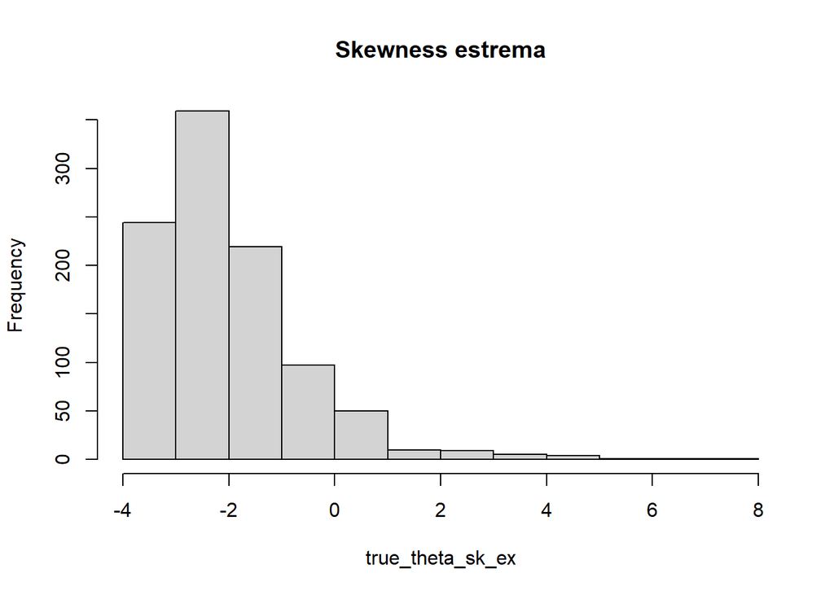

```r
hist(true_theta_sk_ex, main = "Skewness estrema")
```

## Distribuzione uniforme

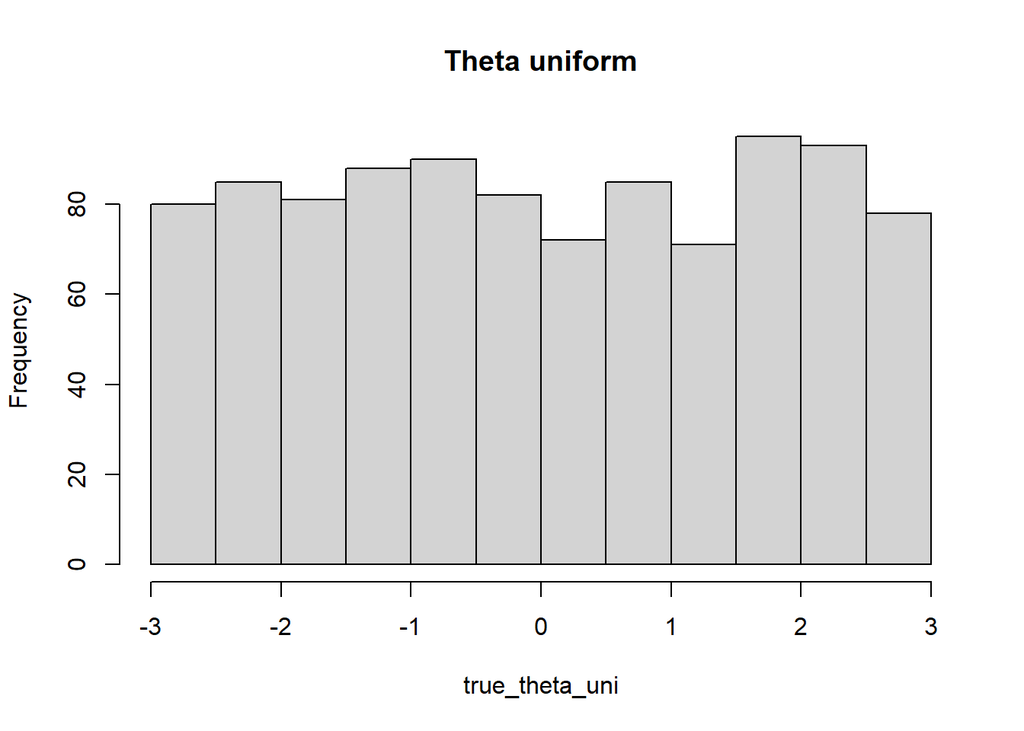

```r
set.seed(666)
true_theta_uni <- c(runif(1000, min = -3, max = 3))
b <- runif(100, -3, 3)
a = c(runif(100, 0.4, 2))
diff_true <- matrix(cbind(1:length(b), b), ncol = 2)
discr_true <- array(c(rep(0, length(a)), a), c(length(a),
    2, 1), dimnames = list(paste0("I", 1:length(a)),
    c("Cat0", "Cat1"), "Dim01"))
data_uni <- sirt::sim.raschtype(true_theta_uni, b = b,
    fixed.a = a)

hist(true_theta_uni, main = "Theta uniform")
```

## Stima del modello inziale

Modello iniziale con tutti gli item stimato come (questo è vero per tutte le distribuzioni):

```r
m2pl <- tam.mml(data, xsi.fixed = diff_true, B = discr_true)
```

## Trovo i valori theta target

SUlla base dei theta osservati

### Guided

```r
ranges <- NULL
groups <- NULL

cut_value <- list()

for (i in 1:(length(num_item))) {
    ranges <- seq(min(true_theta), max(true_theta),
        length = num_item[i])
    groups <- cut(ranges, num_item[i], include.lowest = TRUE)
    cut_value[[i]] <- cut_borders(groups)
    cut_value[[i]]$mean_theta <- rowMeans(cut_value[[i]])
}
```

### Guided new

```r
cut_value <- list()
# tengo solo la prima selezione di item
for (i in 1:length(num_item)) {
    cut_value[[i]] = seq(min(true_theta), max(true_theta),
        length = num_item[i])
}
```

### Cluster

```r
num_clusters <- num_item
theta_mat <- matrix(true_theta, ncol = 1)
info_start <- mean(IRT.informationCurves(m2pl, theta = seq(-3,
    3, length = 1000))$test_info_curve)
# generate clusters

cluster <- list()

for (i in 1:length(num_clusters)) {
    cluster[[i]] <- kmeans(theta_mat, centers = num_clusters[i])
}
```

### Smart

Theta teorico tra -3 e 3

```r
data_info_smart <- data.frame(items = 1:(ncol(data)),
    info = numeric((ncol(data))))

for (i in 1:nrow(data_info_smart)) {
    data_info_smart[i, "info"] <- mean(IRT.informationCurves(m2pl,
        theta = seq(-3, 3, length = 1000), iIndex = lab_item[i])$info_curves_item)

}

# ora scrivi il codice per la procedura iterativa
# dove dato un certo numero di item, trova il
# massimo e mano a mano toglie quel'item
filtro <- list()
data_temp <- list()
for (i in 1:length((num_item))) {
    filtro[[i]] <- data_info_smart[which(data_info_smart$info ==
        max(data_info_smart$info)), ]
    for (j in 1:(num_item[i] - 1)) {
        data_temp[[j]] <- data_info_smart[!data_info_smart$items %in%
            filtro[[i]]$items, ]
        filtro[[i]] <- rbind(filtro[[i]], data_temp[[j]][which(data_temp[[j]]$info ==
            max(data_temp[[j]]$info)), ])
    }
    names(filtro)[[i]] <- paste("number", num_item[i],
        sep = "")

}
```

## Calcolo informatività per ogni theta target

```r
info_test <- NULL
temp <- list()
value <- list()
temp_data <- NULL
info_data <- NULL

for (j in 1:length(cut_value)) {
    # contiene i theta target
    value[[j]] <- cut_value[[j]][1:nrow(cut_value[[j]]),
        ]

    for (i in 1:length(lab_item)) {
        # per ognuno dei 100 item viene calcolata l'info
        # per ogni theta target
        for (m in 1:nrow(value[[j]])) {

            temp_data <- data.frame(theta_target = IRT.informationCurves(m2pl,
                theta = value[[j]][m, "mean_theta"],
                iIndex = lab_item[i])$theta, test_info = mean(IRT.informationCurves(m2pl,
                theta = value[[j]][m, "mean_theta"],
                iIndex = lab_item[i])$test_info_curve),
                item_info = mean(colSums(IRT.informationCurves(m2pl,
                  theta = value[[j]][m, "mean_theta"],
                  iIndex = lab_item[i])$info_curves_item)),
                item = lab_item[i], num_item = paste("number",
                  nrow(value[[j]]), sep = ""))

            info_data <- rbind(info_data, temp_data)  # data frame dove per ogni theta target si ha
        }  # l'info di ogni item
    }
}
```

## Calcolo info massima di ogni item per uno specifico theta target

```r
temp_data <- NULL
temp_maxrange <- NULL
temp <- NULL
max_temp <- NULL

for (i in 1:length(unique(info_data$num_item))) {
    temp_data <- info_data[info_data$num_item %in%
        unique(info_data$num_item)[i], ]
    temp_maxrange <- aggregate(test_info ~ item + theta_target,
        data = temp_data, max)
    temp_maxrange$range_name <- unique(temp_data$num_item)  # trova l'item maggiormente informativo
    # per ogni theta target toglie l'item e il theta e
    # ricomincia da capo
    for (j in 1:length(unique(temp_maxrange$theta_target))) {
        temp <- temp_maxrange[which(temp_maxrange$test_info ==
            max(temp_maxrange$test_info)), ]
        temp_maxrange <- temp_maxrange[which(temp_maxrange$item !=
            temp$item & temp_maxrange$theta_target !=
            temp$theta_target), ]
        max_temp <- rbind(max_temp, temp)

    }
}
```

## Stimo in maniera ricorsiva il modello selezionando gli item trovati al punto precedente

### Parametri degli item liberi

```r
 out_range <- list()
  model_out_range <- list()
  info_out_range <- list()

  for (i in 1:length(unique(max_temp$range_name))) {
    out_range[[i]] <- data[, c(max_temp[max_temp$range_name %in%unique(max_temp$range_name)[i],
                                        "item"])]
    model_out_range[[i]] <- tam.mml.2pl(out_range[[i]]) # stimo il modello
    info_out_range[[i]] <- IRT.informationCurves(model_out_range[[i]], # calcolo info del modello
                                                 theta = seq(-3, 3, length = 1000))
    names(info_out_range)[[i]] <- unique(max_temp$range_name)[i]
  }
```

### Parametri degli item vincolati

```r
 out_range_theta <- list()
  model_out_range_theta <- list()
  info_out_range_theta <- list()

  for (i in 1:length(unique(max_temp$range_name))) {
    out_range_theta[[i]] <- data[, c(max_temp[max_temp$range_name %in%unique(max_temp$range_name)[i],
                                              "item"])]
    model_out_range_theta[[i]] <- tam.mml(out_range_theta[[i]], # stimo il modello tenendo
                                              # gli item fissi ma selezionando
                                          # solo i parametri degli item selezionati
                                              xsi.fixed =
                                            cbind(1:ncol(out_range_theta[[i]]),
                                                  diff_true[as.integer(gsub("I00|I0|I",
                                                                            '',
                                                            colnames(out_range_theta[[i]]))), 2]),
                                              B =
                                            array(c(rep(0, ncol(out_range_theta[[i]])),
                                                     discr_true[,2,][as.integer(gsub("I00|I0|I",
                                                                                "",
                                                                    colnames(out_range_theta[[i]])))]),
                                                   c(ncol(out_range_theta[[i]]),2,1),
                                                   dimnames = list(colnames(out_range_theta[[i]]),
                                                                   c("Cat0", "Cat1"),
                                                                   "Dim01")))
    info_out_range_theta[[i]] <- IRT.informationCurves(model_out_range_theta[[i]],
                                                       theta = seq(-3, 3, length = 1000))
    names(info_out_range_theta)[[i]] <- unique(max_temp$range_name)[i]
  }
```

## Calcolo info nuovi modelli e reliability

(Stesso codice per i modelli stimati tenendo fissi i parametri degli item)

```r
  info_summary_range <- NULL
  temp <- NULL
  for(i in 1:length(info_out_range)) {
    temp <- data.frame(info_test = mean(info_out_range[[i]]$test_info_curve),


                       range_name = names(info_out_range)[[i]],
                       item = paste(colnames(out_range[[i]]), collapse = ","))

    info_summary_range <- rbind(info_summary_range,
                                temp)
  }

  info_summary_range$rel <- 1 - (1/sqrt(info_summary_range$info_test))^2
  info_summary_range <-  rbind(info_summary_range,
                               data.frame(info_test = sum(info_start),
                                          range_name = "all",
                                          item = "all",
                                          rel = 1 - (1/sqrt(info_start))^2))
  info_summary_range$selection <- "guided"
```

## TIF con tutti gli item

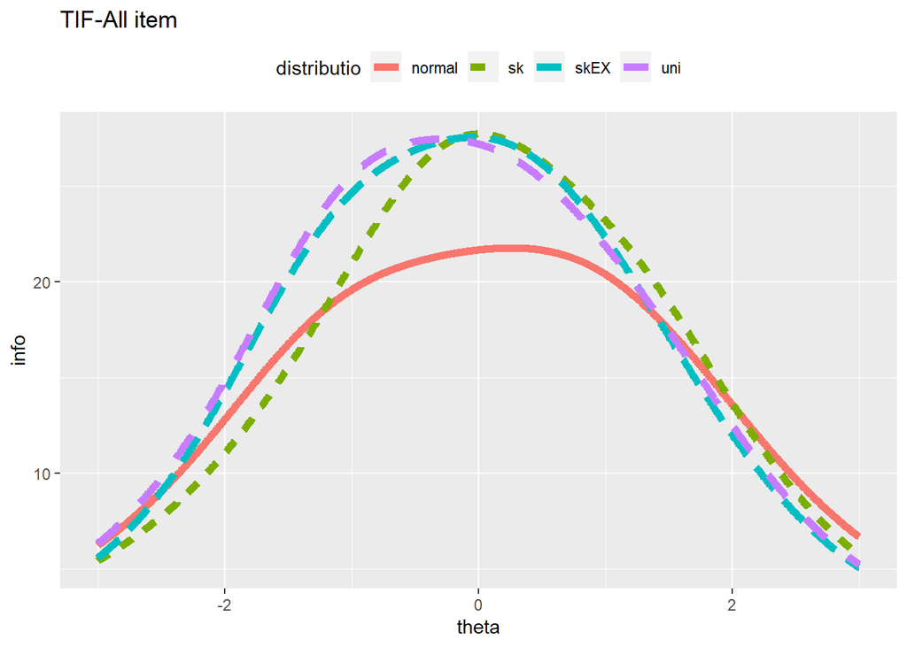

## Tif gruppi di item

Normale Parametri liberi

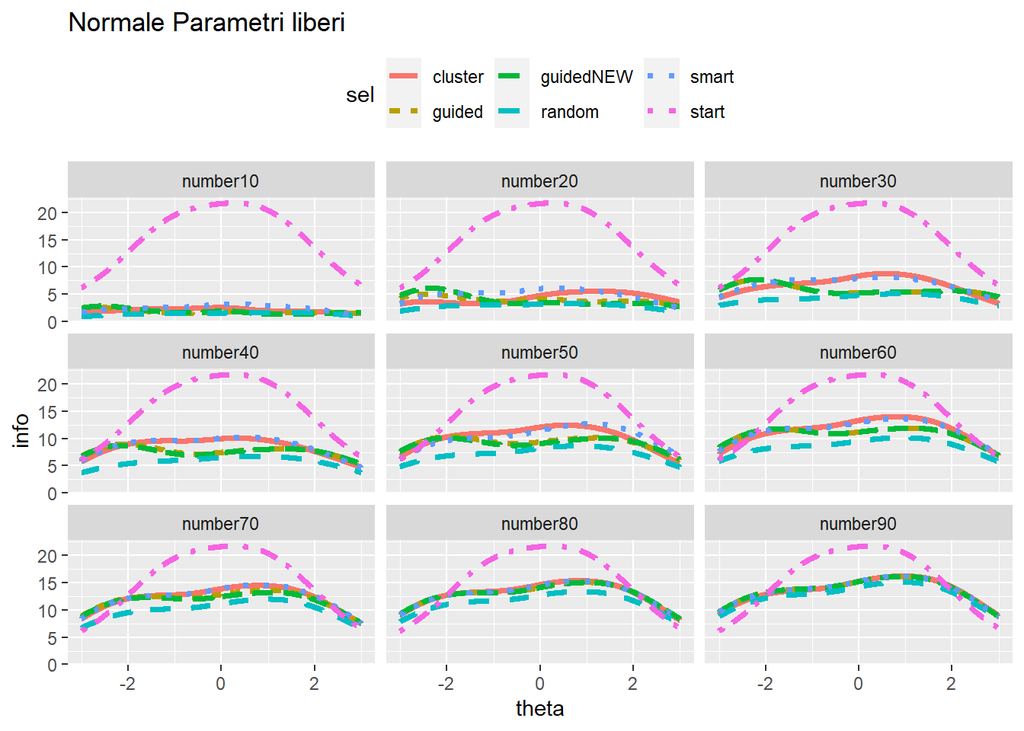

Normale parametri fissi:

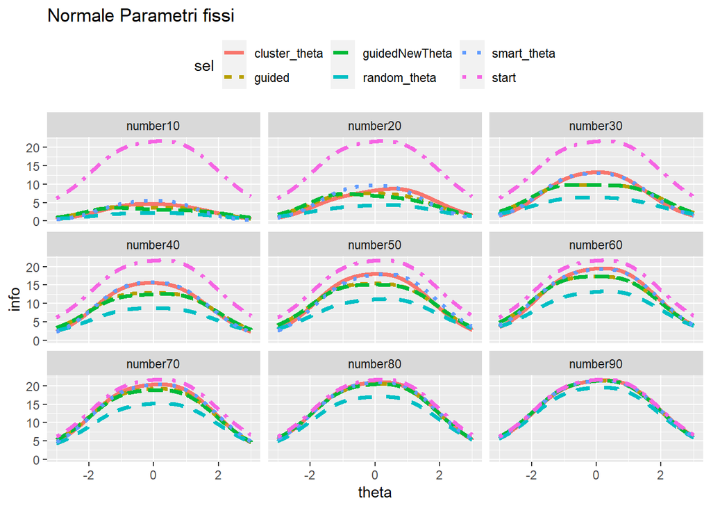

Skewness parametri liberi

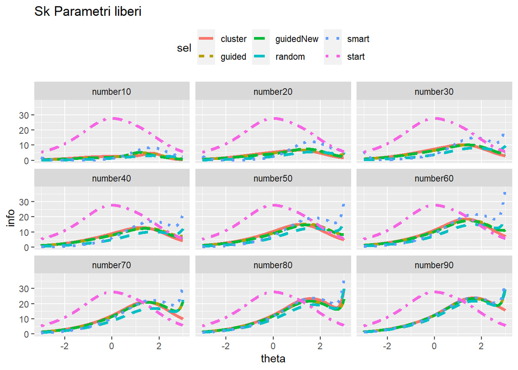

Parametri liberi SK estrema

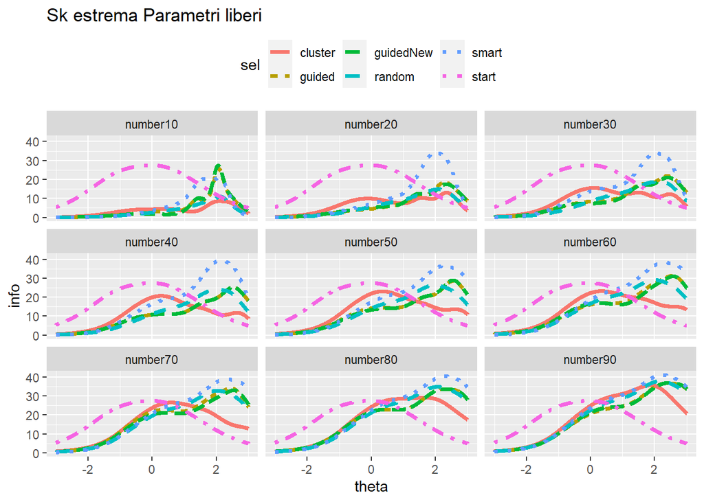

```r
ggplot(temp_graph_sk_ex, aes(x = theta, y = info, group = sel,
    col = sel)) + geom_line(aes(linetype = sel), lwd = 1.4) +
    facet_wrap(~num_item) + theme(legend.position = "top") +
    ggtitle("Sk estrema Parametri liberi")
```

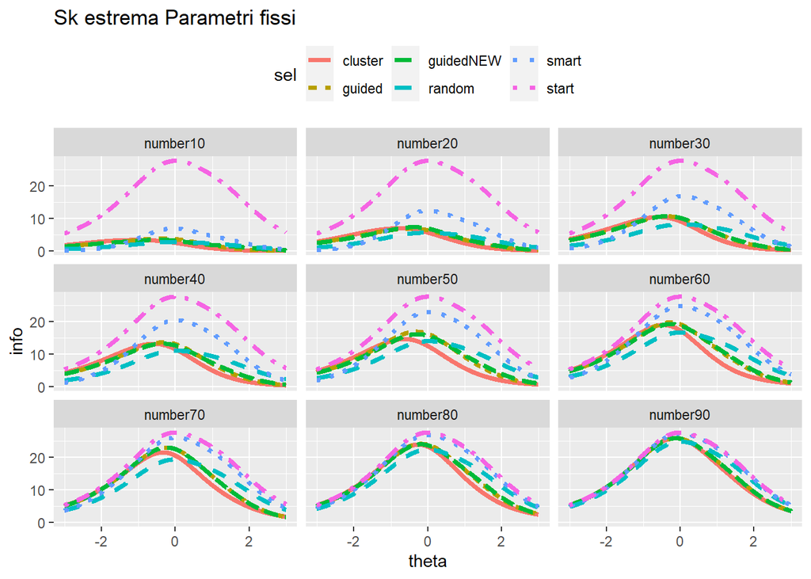

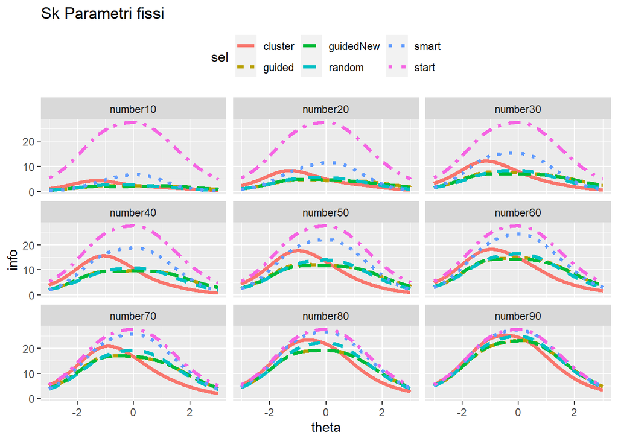

Uniforme parametri liberi

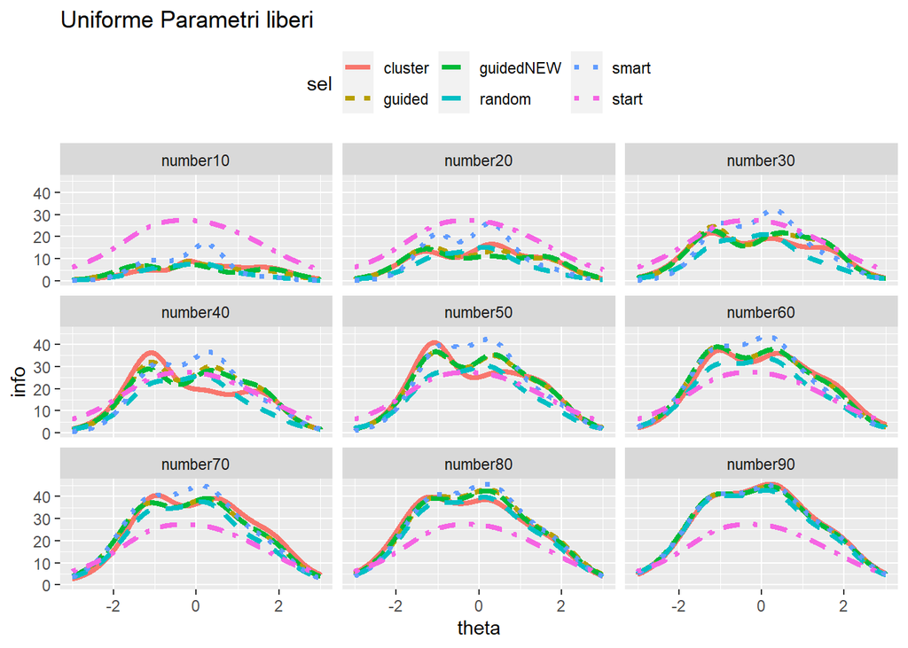

Parametri fissi uniforme

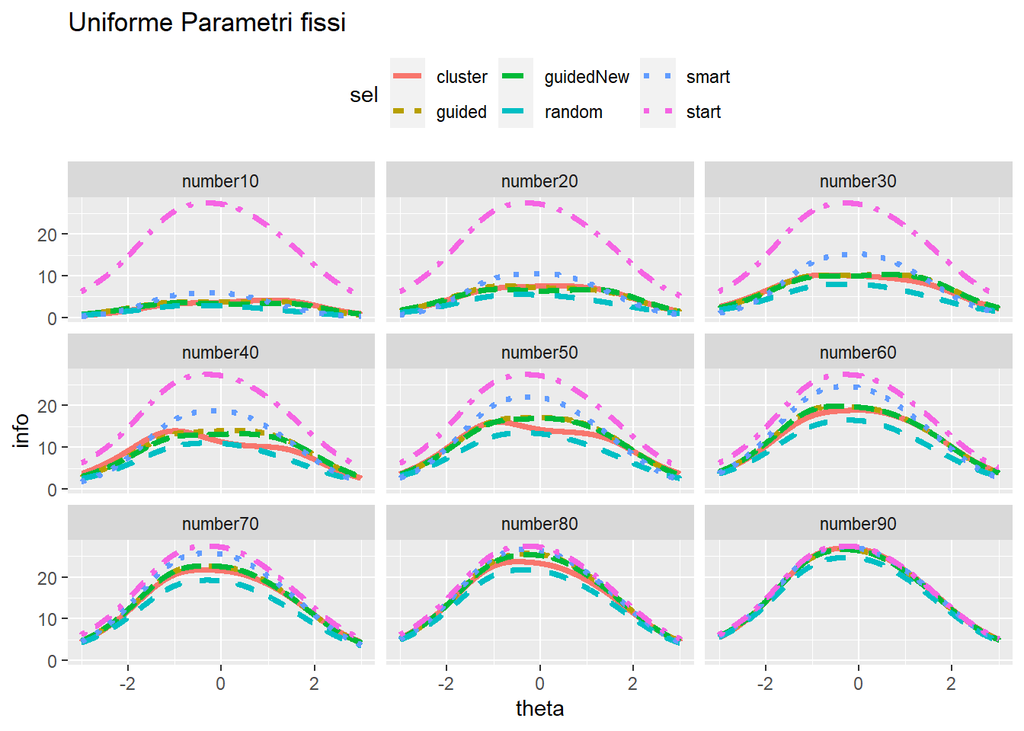

## Informazione

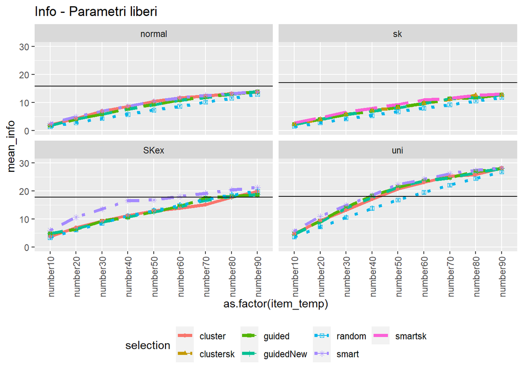

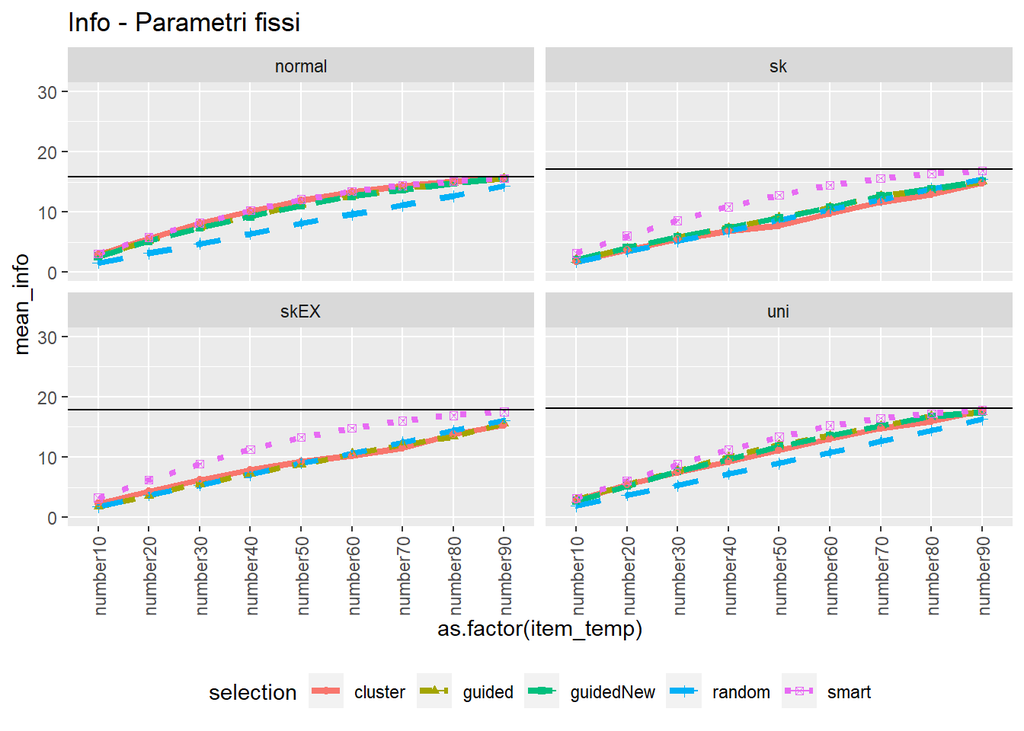

## Reliability

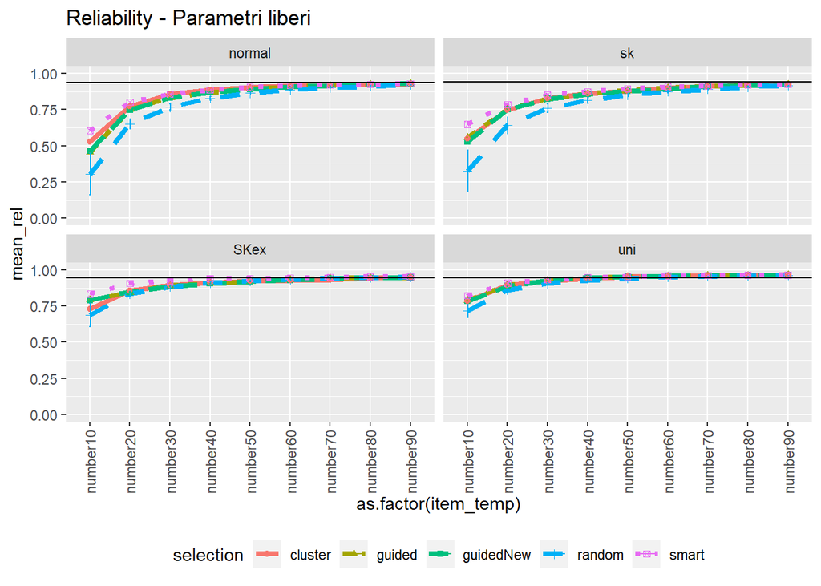

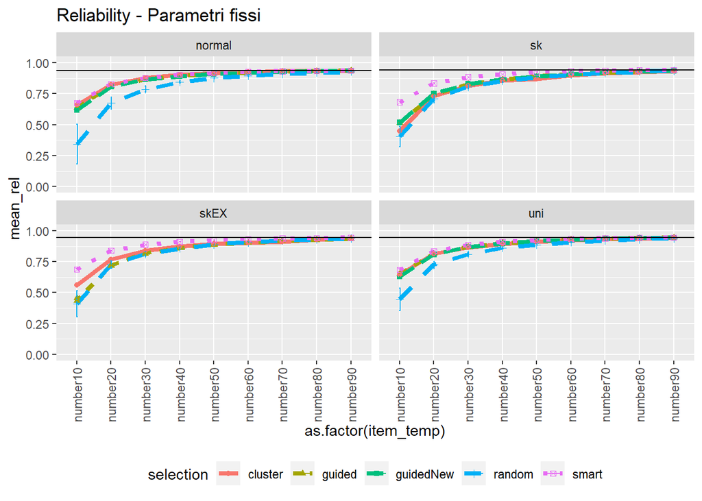

## Bias assoluto

La differenza è calcolata tra i $\theta$ calcolati per ognuno dei diversi nuovi nuovi test e i $\theta$ stimati sul modello con tutti gli item.

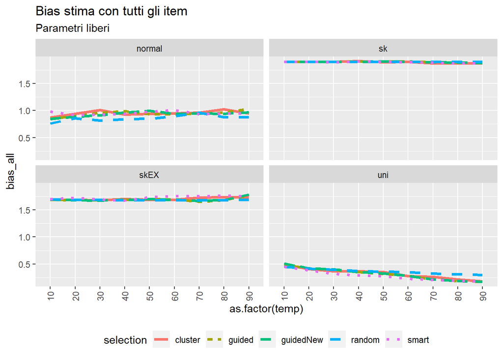

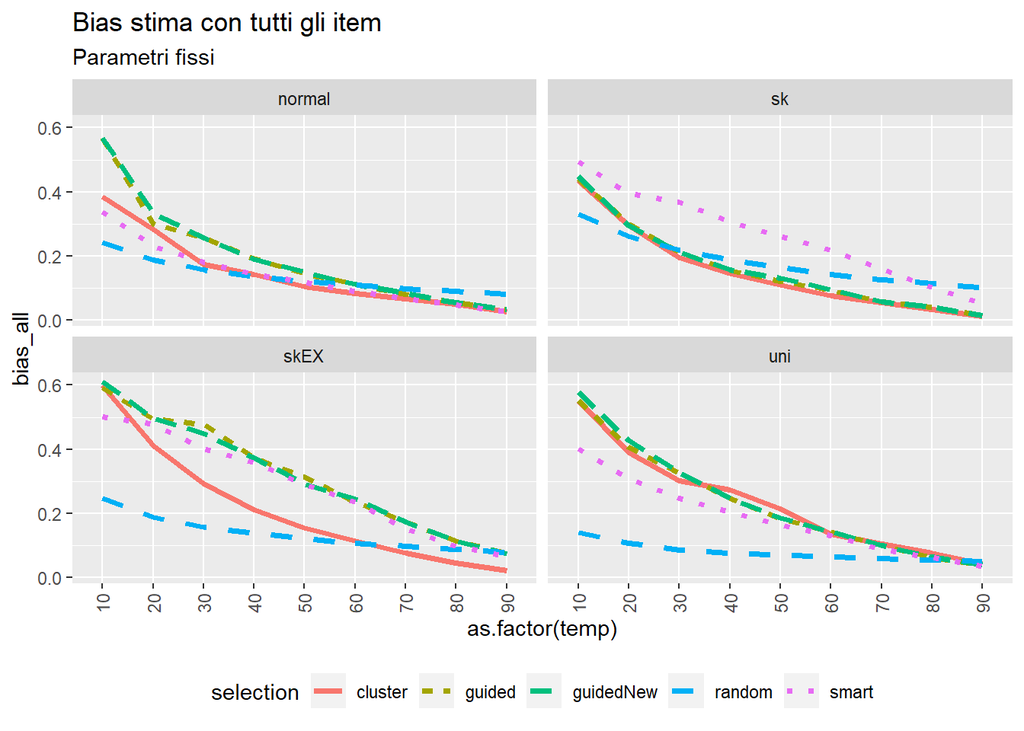

## RMSE

La differenza è calcolata tra i $\theta$ calcolati per ognuno dei diversi nuovi nuovi test e i $\theta$ stimati sul modello con tutti gli item.

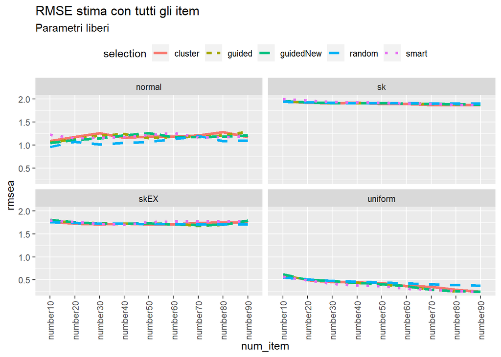

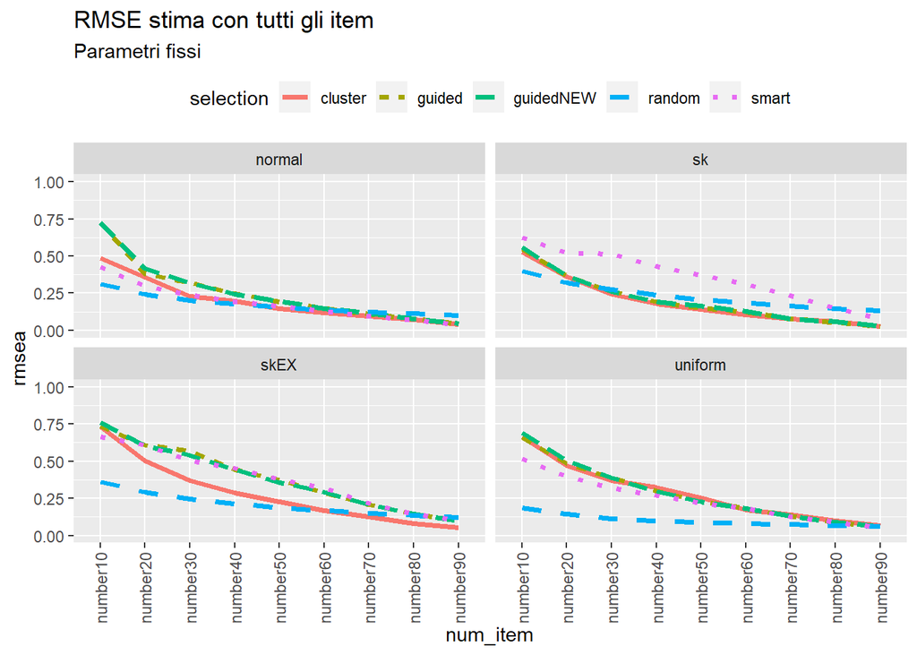

## Bias assoluto valori osservati

La differenza è calcolata tra i $\theta$ calcolati per ognuno dei diversi nuovi nuovi test e i $\theta$ “veri” (quelli simulati all’inizio, che quindi possono avere distribuzione normale, con skewness o uniforme).

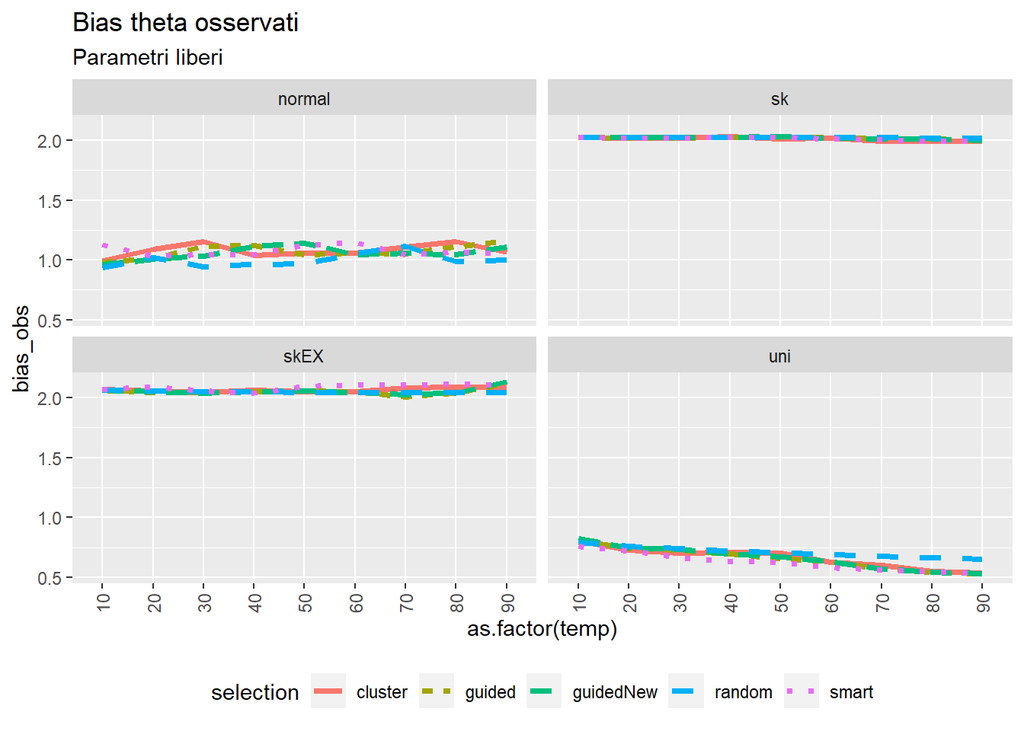

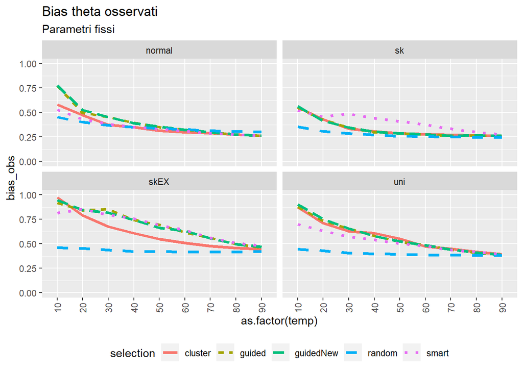

## RMSE valori osservati

La differenza è calcolata tra i $\theta$ calcolati per ognuno dei diversi nuovi nuovi test e i $\theta$ “veri” (quelli simulati all’inizio, che quindi possono avere distribuzione normale, con skewness o uniforme).

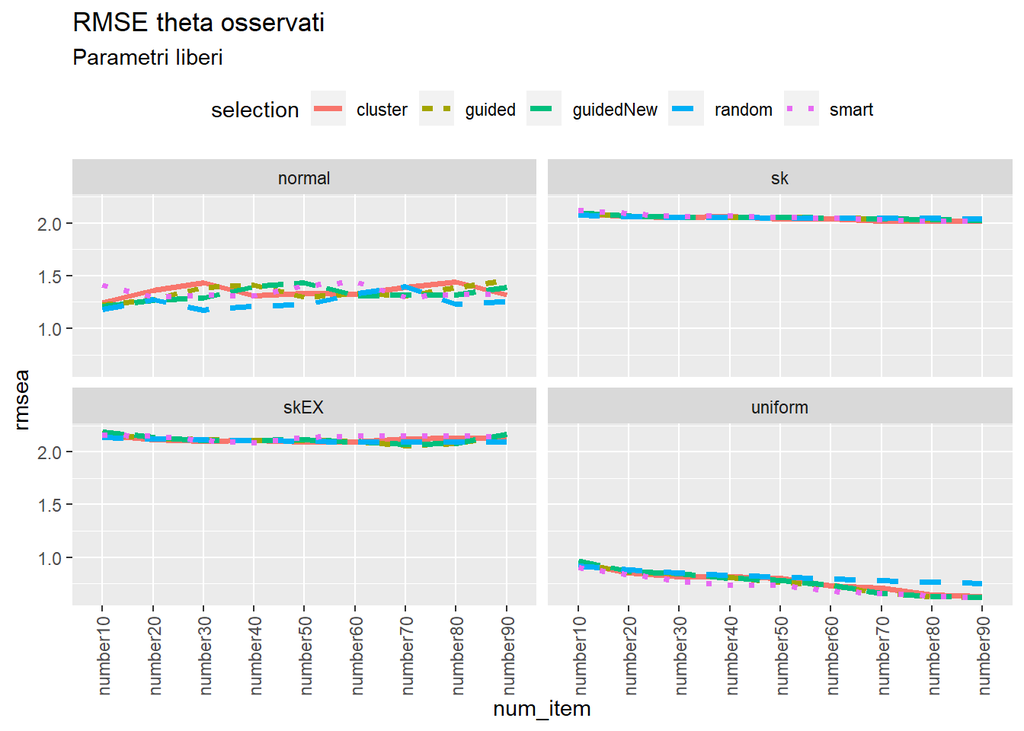

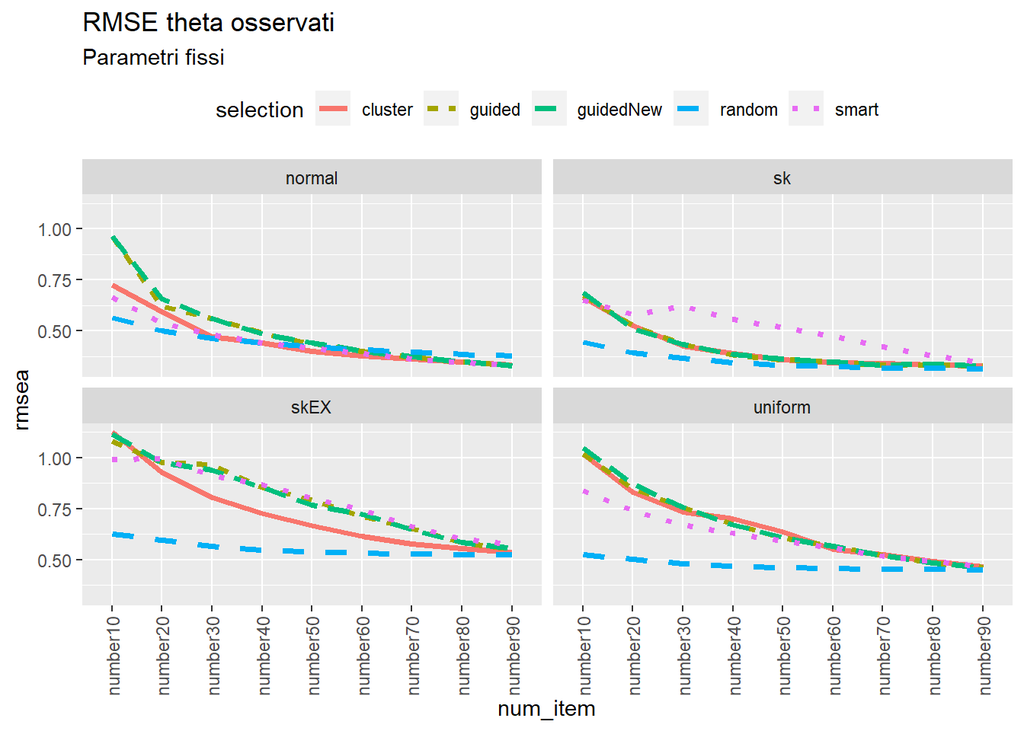

# Bias assoluto per gruppi di theta

La differenza è calcolata tra i $\theta$ calcolati per ognuno dei diversi nuovi nuovi test e i $\theta$ “veri” (quelli simulati all’inizio, che quindi possono avere distribuzione normale, con skewness o uniforme).

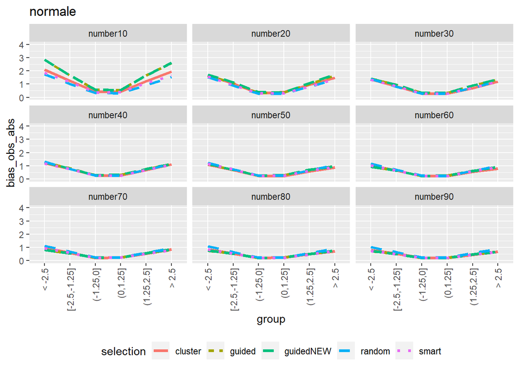

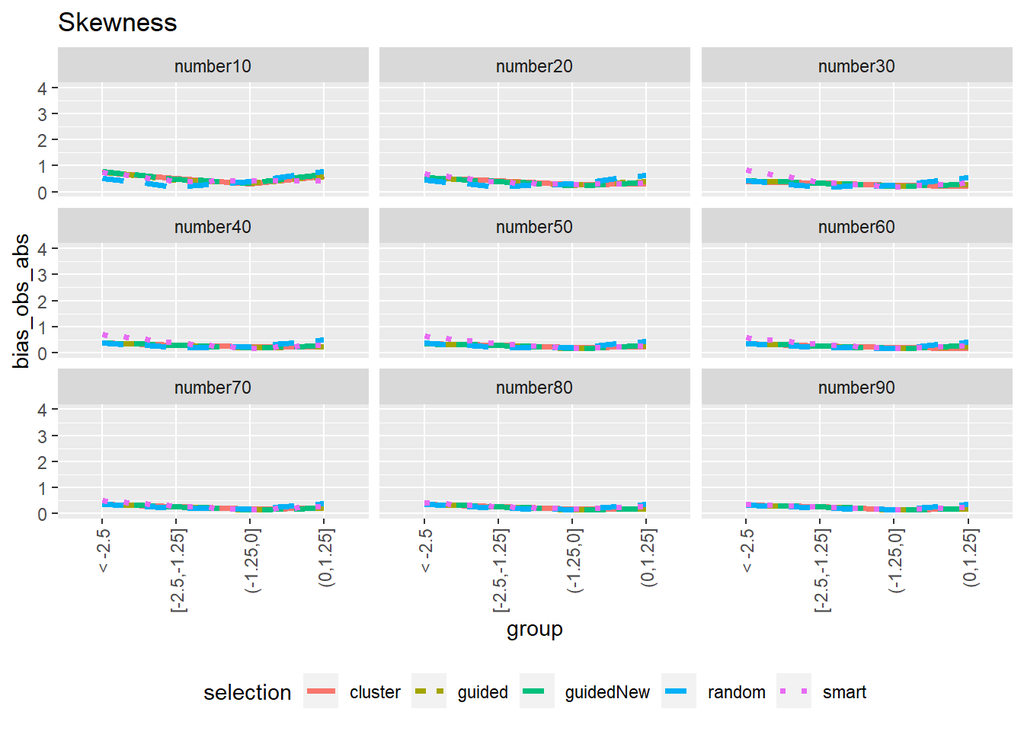

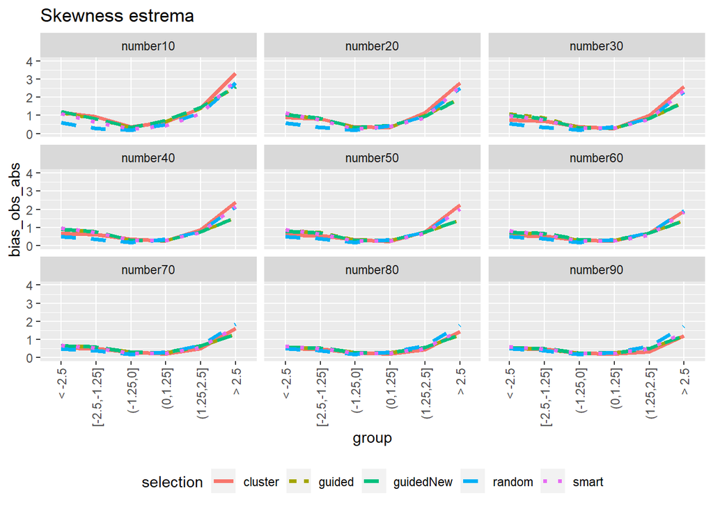

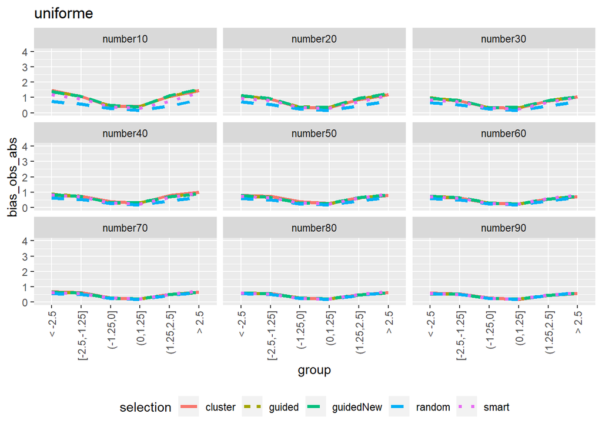

# Bias per gruppi di theta

La differenza è calcolata tra i $\theta$ calcolati per ognuno dei diversi nuovi nuovi test e i $\theta$ “veri” (quelli simulati all’inizio, che quindi possono avere distribuzione normale, con skewness o uniforme).

A differenza del punto precedente, il bias non ha il valore assoluto. Essendo $\hat{\theta} - \theta$, valori positivi indicano sovrastima, valori negativi indicano sottostima.

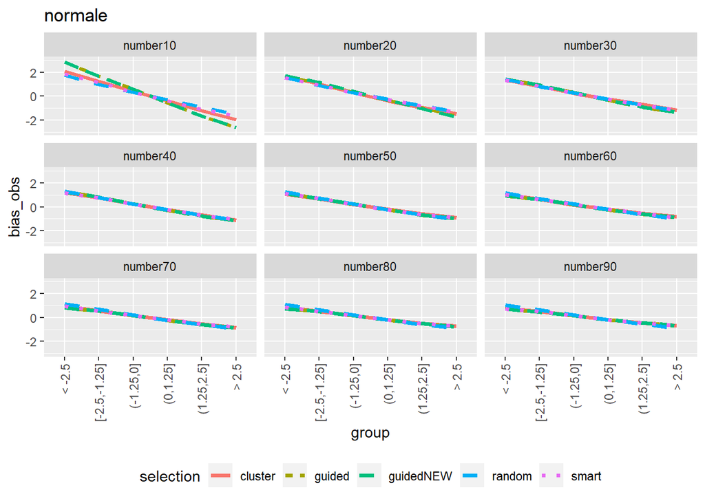

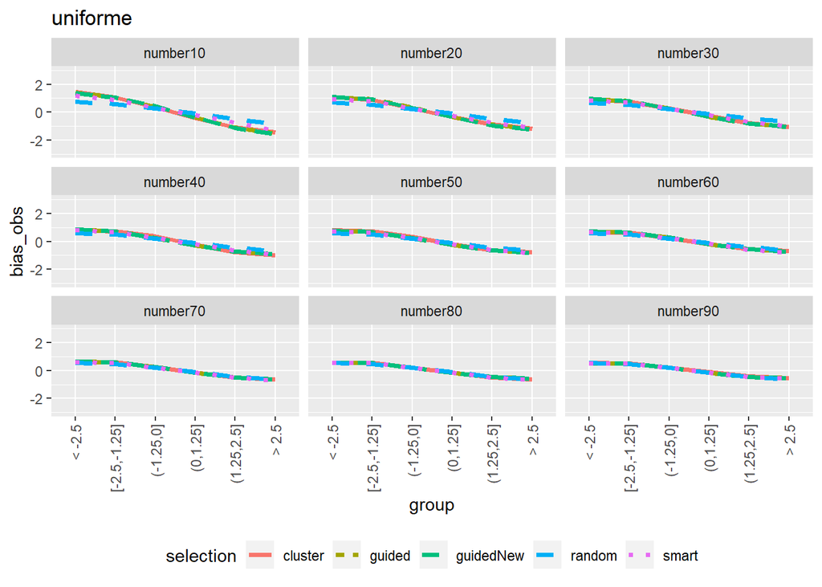

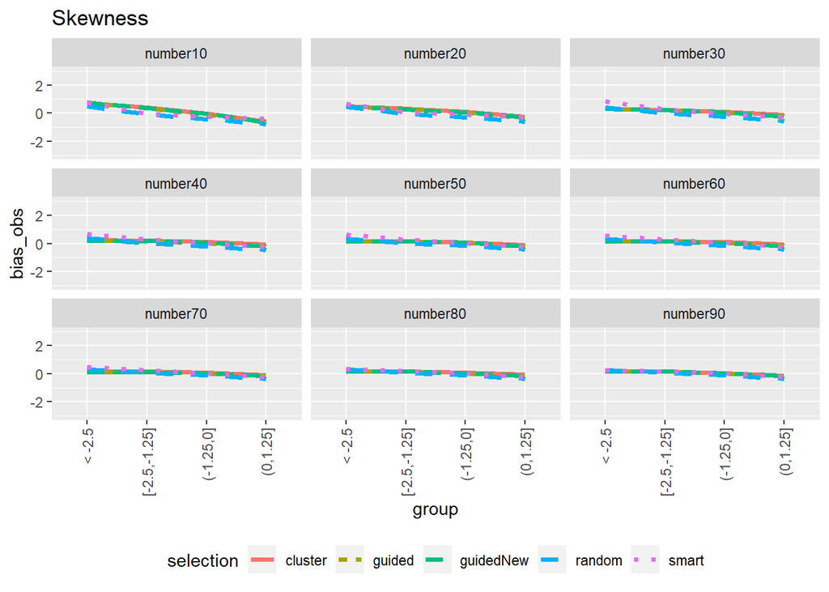

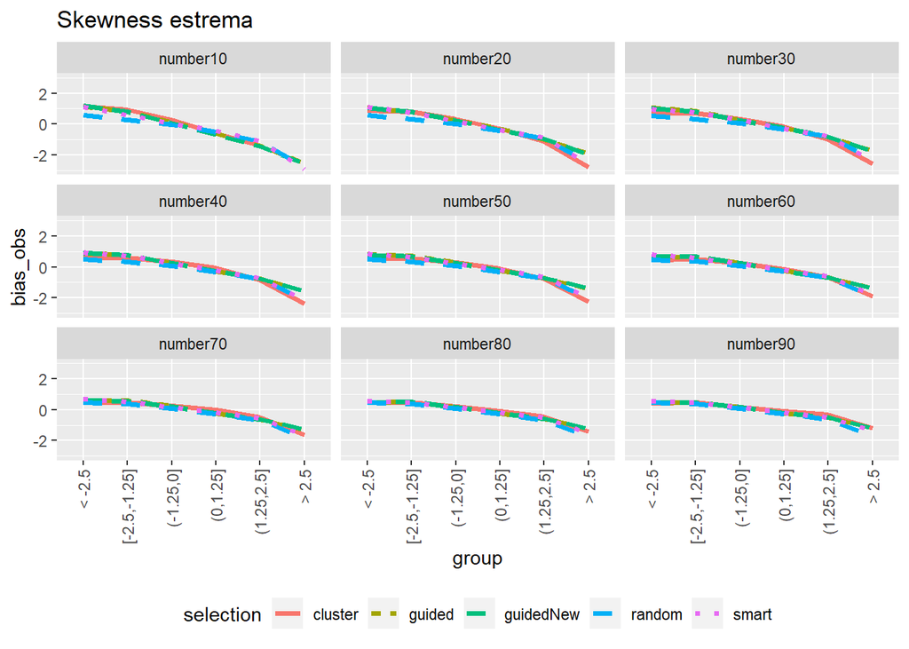

## RMSE per gruppi di theta

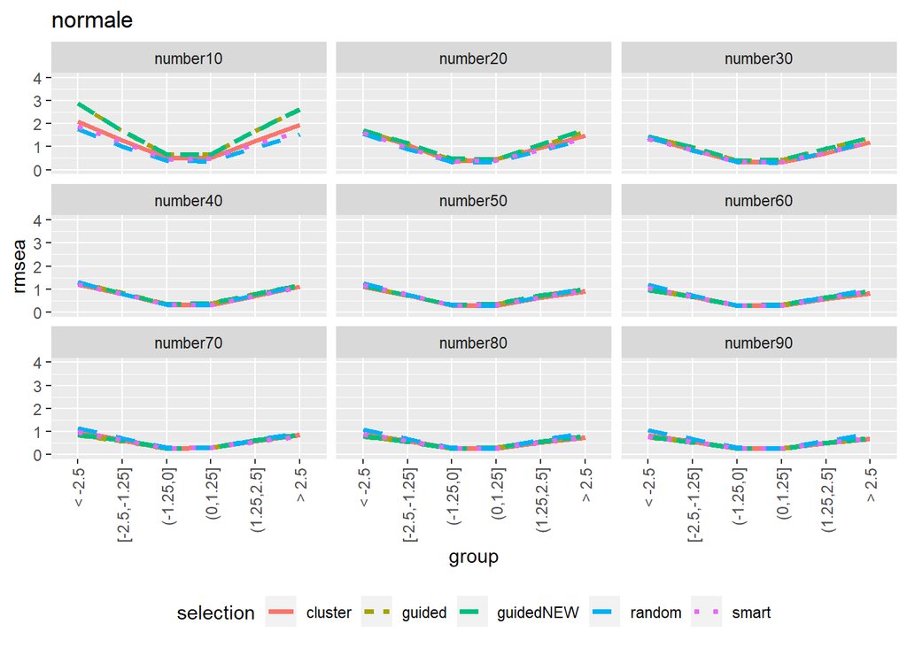

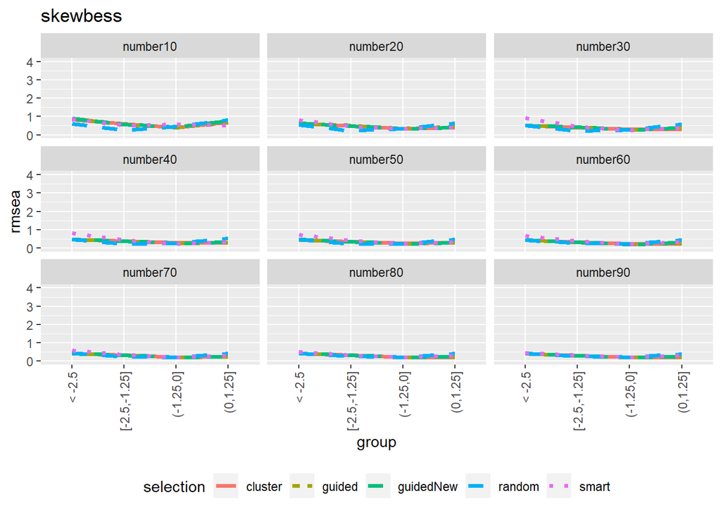

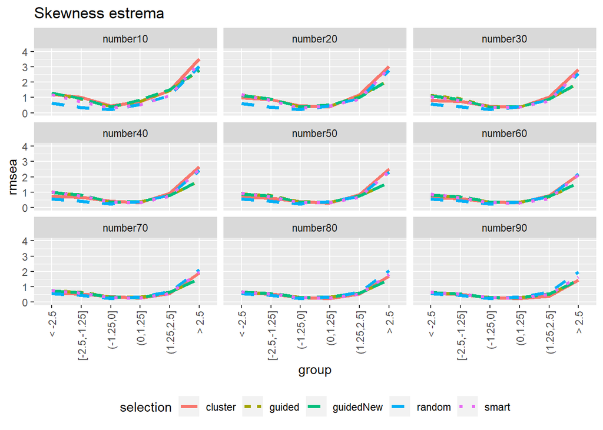

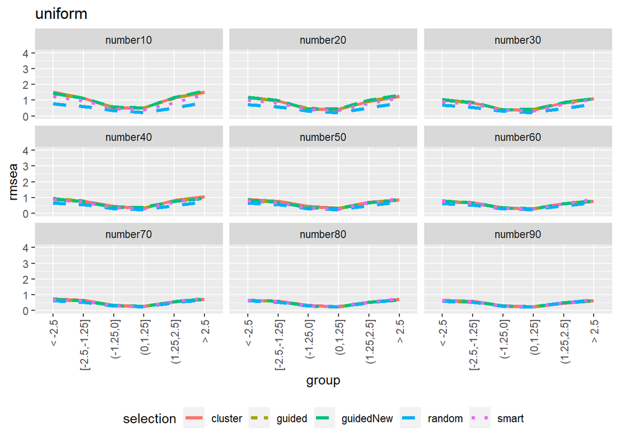